# Unit 2: EDA Modeling

Author

Key

Published

January 22, 2026

## Packages, Source, Etc

> This code chunk loads in our tidy packages – we always load these first.

```r
library(tidyverse) # for general data wrangling
library(tidymodels) # for modeling
```

> This code chunk will set up conflict policies to reduce errors associated with function conflicts.

```r
options(conflicts.policy = "depends.ok")
```

> This code chunk loads all other packages you will need for this assignment.

```r
library(kableExtra, exclude = "group_rows") # you may or may not use this one!
library(cowplot, include.only = c("plot_grid", "theme_half_open"))
library(corrplot, include.only = "corrplot.mixed") # or just use namespace
```

> Source John’s function scripts.

```r
source("https://github.com/jjcurtin/lab_support/blob/main/fun_eda.R?raw=true")
source("https://github.com/jjcurtin/lab_support/blob/main/fun_plots.R?raw=true")
```

> Set up some other environment settings.

```r
options(tibble.width = Inf, tibble.print_max = Inf)
theme_set(theme_half_open()) # maybe you prefer this to classic theme?
```

> In the chunk below, set path_data to the location of your cleaned data files.

```r
path_data <- "application_assignments/unit_02"
```

## Read and set up data

### Read data

> Load the cleaned training dataset and do skim/glimpse it to get oriented.

```r
data_trn <- read_csv(here::here(path_data, "ames_clean_class_trn.csv"),
                     show_col_types = FALSE) |>
  glimpse()
```

```
Rows: 1,465
Columns: 10
$ sale_price      <dbl> 105000, 126000, 115000, 127500, 120000, 99500, 125000,…
$ garage_area     <dbl> 730, 525, 0, 440, 308, 264, 264, 429, 539, 260, 0, 0, …
$ neighborhood    <chr> "names", "names", "names", "npkvill", "npkvill", "sawy…
$ ms_sub_class    <chr> "020", "020", "020", "120", "120", "120", "120", "030"…
$ total_bsmt_sf   <dbl> 882, 882, 864, 1069, 836, 918, 744, 816, 0, 1040, 950,…
$ bsmt_qual       <chr> "ta", "ta", "ta", "gd", "gd", "gd", "gd", "ta", "no_bs…
$ central_air     <chr> "y", "y", "y", "y", "y", "y", "y", "n", "y", "y", "y",…
$ tot_rms_abv_grd <dbl> 5, 4, 5, 4, 4, 5, 4, 5, 8, 6, 6, 10, 4, 6, 6, 6, 5, 4,…
$ fireplaces      <dbl> 0, 0, 1, 1, 0, 1, 0, 0, 0, 0, 0, 0, 0, 0, 0, 0, 0, 0, …
$ fireplace_qu    <chr> "no_fireplace", "no_fireplace", "po", "fa", "no_firepl…
```

### Set up variable classes

> As before, set up all categorical variables as factors (and confirm order if needed) and set up interval/ration variables as numeric.

Remember that we will oftentimes need to reclass variables after loading them in again because .csv formats do not preserve variable types or other metadata.

```r
# note use of suppressWarnings().  Once you understand a warning, it's often good practice
# to suppress it so that you know you've resolved it.
data_trn <- data_trn |>
  mutate(across(where(is.character), factor)) |>
  mutate(bsmt_qual = suppressWarnings(fct_relevel(bsmt_qual, c("no_bsmt", "po", "fa",
                                                  "ta", "gd", "ex"))),
         fireplace_qu = fct_relevel(fireplace_qu, c("no_fireplace", "po", "fa",
                                                  "ta", "gd", "ex"))) |>
  glimpse()
```

```
Rows: 1,465
Columns: 10
$ sale_price      <dbl> 105000, 126000, 115000, 127500, 120000, 99500, 125000,…
$ garage_area     <dbl> 730, 525, 0, 440, 308, 264, 264, 429, 539, 260, 0, 0, …
$ neighborhood    <fct> names, names, names, npkvill, npkvill, sawyerw, sawyer…
$ ms_sub_class    <fct> 020, 020, 020, 120, 120, 120, 120, 030, 090, 020, 020,…
$ total_bsmt_sf   <dbl> 882, 882, 864, 1069, 836, 918, 744, 816, 0, 1040, 950,…
$ bsmt_qual       <fct> ta, ta, ta, gd, gd, gd, gd, ta, no_bsmt, ta, ta, ta, t…
$ central_air     <fct> y, y, y, y, y, y, y, n, y, y, y, y, y, y, y, y, y, y, …
$ tot_rms_abv_grd <dbl> 5, 4, 5, 4, 4, 5, 4, 5, 8, 6, 6, 10, 4, 6, 6, 6, 5, 4,…
$ fireplaces      <dbl> 0, 0, 1, 1, 0, 1, 0, 0, 0, 0, 0, 0, 0, 0, 0, 0, 0, 0, …
$ fireplace_qu    <fct> no_fireplace, no_fireplace, po, fa, no_fireplace, ta, …
```

```r
data_trn |>
  skim_all() # big picture view of the data
```

Data summary

| Name | data_trn |
| --- | --- |
| Number of rows | 1465 |
| Number of columns | 10 |
| _______________________ |  |
| Column type frequency: |  |
| factor | 5 |
| numeric | 5 |
| ________________________ |  |
| Group variables | None |

**Variable type: factor**

| skim_variable | n_missing | complete_rate | n_unique | top_counts |
| --- | --- | --- | --- | --- |
| neighborhood | 0 | 1 | 28 | nam: 216, col: 124, old: 121, edw: 100 |
| ms_sub_class | 0 | 1 | 15 | 020: 544, 060: 289, 050: 160, 120: 94 |
| bsmt_qual | 0 | 1 | 5 | ta: 636, gd: 611, ex: 125, fa: 51 |
| central_air | 0 | 1 | 2 | y: 1367, n: 98 |
| fireplace_qu | 0 | 1 | 6 | no_: 703, gd: 359, ta: 314, fa: 37 |

**Variable type: numeric**

| skim_variable | n_missing | complete_rate | mean | sd | p0 | p25 | p50 | p75 | p100 | skew | kurtosis |
| --- | --- | --- | --- | --- | --- | --- | --- | --- | --- | --- | --- |
| sale_price | 0 | 1 | 180761.93 | 79016.72 | 13100 | 129500.0 | 160000 | 213500 | 745000 | 1.67 | 4.59 |
| garage_area | 1 | 1 | 473.56 | 214.12 | 0 | 321.5 | 480 | 577 | 1488 | 0.18 | 1.01 |
| total_bsmt_sf | 0 | 1 | 1047.90 | 439.71 | 0 | 780.0 | 992 | 1314 | 6110 | 1.26 | 12.12 |
| tot_rms_abv_grd | 0 | 1 | 6.47 | 1.55 | 3 | 5.0 | 6 | 7 | 14 | 0.76 | 1.19 |
| fireplaces | 0 | 1 | 0.60 | 0.64 | 0 | 0.0 | 1 | 1 | 3 | 0.66 | -0.17 |

## Univariate Distributions

### Numeric variables

> First examine the univariate distributions of your numeric variables. While you can use multiple strategies to examine these data (quantitative and visual), you must also use `map()` to iterate through all numeric variables and create a `plot_grid` in a single piped chain. Describe what you discover about your data.

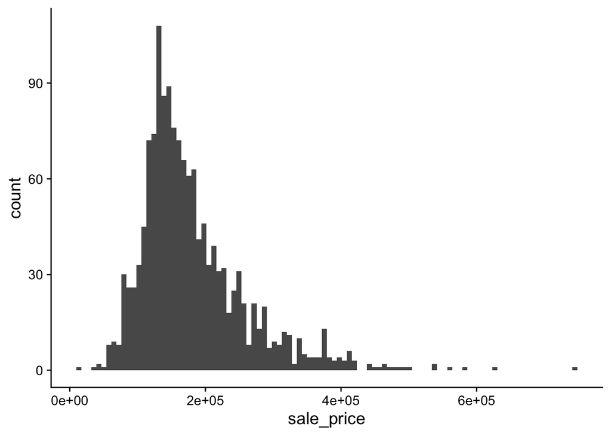

```r
# You only need one of these -- which do you prefer?
data_trn |> plot_hist("sale_price") # histogram
```

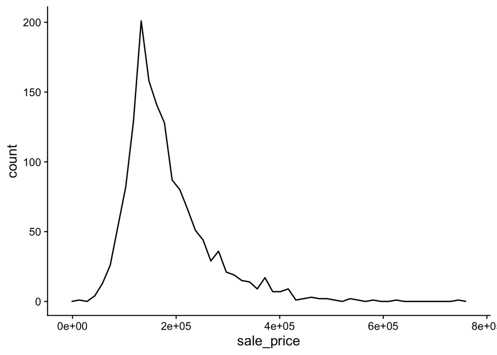

```r
data_trn |> plot_freqpoly("sale_price") # frequency polygon
```

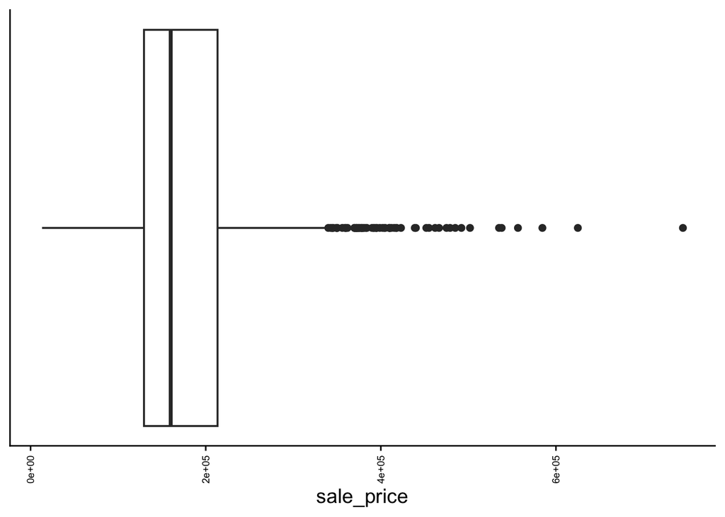

```r
# Boxplots can give you some additional info about outliers
data_trn |> plot_boxplot("sale_price") # boxplot
```

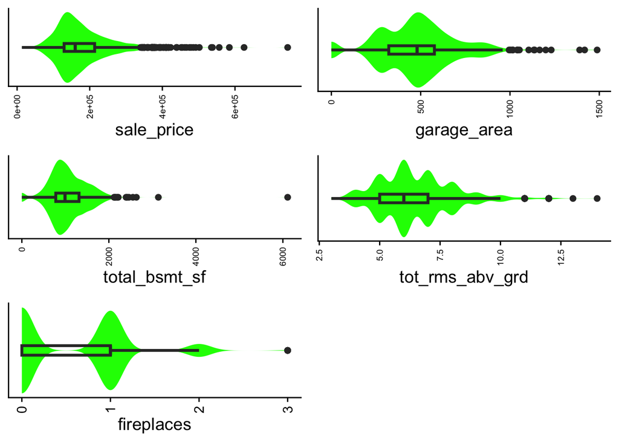

```r
# The warning below is due to the missing value for garage_area
# We'll see that on the next skim!
# In a later code chunk we show how to resolve this by filtered out NAs temporarily
data_trn |>
  select(where(is.numeric)) |>
  names() |>
  map(\(name) plot_box_violin(df = data_trn, x = name)) |> # box violin plot
  plot_grid(plotlist = _, ncol = 2)
```

```r
# Summary statistics
data_trn |>
  skim_all() |>
  filter(skim_type == "numeric")
```

Data summary

| Name | data_trn |
| --- | --- |
| Number of rows | 1465 |
| Number of columns | 10 |
| _______________________ |  |
| Column type frequency: |  |
| numeric | 5 |
| ________________________ |  |
| Group variables | None |

**Variable type: numeric**

| skim_variable | n_missing | complete_rate | mean | sd | p0 | p25 | p50 | p75 | p100 | skew | kurtosis |
| --- | --- | --- | --- | --- | --- | --- | --- | --- | --- | --- | --- |
| sale_price | 0 | 1 | 180761.93 | 79016.72 | 13100 | 129500.0 | 160000 | 213500 | 745000 | 1.67 | 4.59 |
| garage_area | 1 | 1 | 473.56 | 214.12 | 0 | 321.5 | 480 | 577 | 1488 | 0.18 | 1.01 |
| total_bsmt_sf | 0 | 1 | 1047.90 | 439.71 | 0 | 780.0 | 992 | 1314 | 6110 | 1.26 | 12.12 |
| tot_rms_abv_grd | 0 | 1 | 6.47 | 1.55 | 3 | 5.0 | 6 | 7 | 14 | 0.76 | 1.19 |
| fireplaces | 0 | 1 | 0.60 | 0.64 | 0 | 0.0 | 1 | 1 | 3 | 0.66 | -0.17 |

**Numeric Univariate Notes:** *`sale_price`, `garage_area`, and `tot_bsmt_sf` show positive skews, though the skew in `tot_bsmt_sf` may be driven by a handful of outliers (vs `sale_price` which has a high number of outliers and `garage_area` which has a moderate number of outliers). `fireplaces` appears mostly bimodal due to roughly equal numbers of homes having no vs any fireplace (with those who have one being significantly more likely to have only one fireplace, and the 3 fireplace observation appears to be an outlier). `tot_rms_abv_grd` may have a few outlier observations above ten rooms.*

### Categorical variables

> Now examine univariate distributions of your categorical variables. While you can use multiple strategies to examine these data (quantitative and visual), you must also use `map()` to iterate through all categorical variables and create a `plot_grid` in a single piped chain. Comment below on what stands out to you from these plots. Document the questions that arise from inspecting the data in this way.

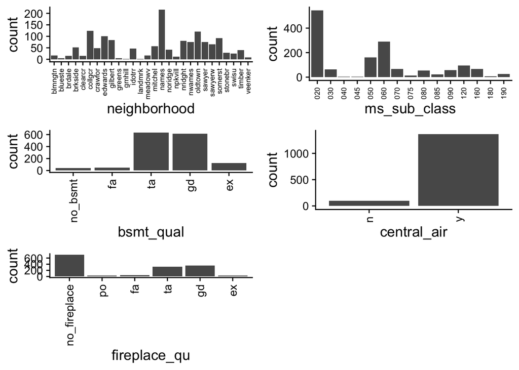

```r
# Bar plots
data_trn |>
  select(where(is.factor)) |>
  names() |>
  map(\(name) plot_bar(df = data_trn, x = name)) |>
  plot_grid(plotlist = _, ncol = 2)
```

```r
# Table
# Maybe you like a table?  I think the above plot is still easier to digest
# though maybe the table makes clear how few observations there are in some
# categories
data_trn |> tab(ms_sub_class)
```

```
# A tibble: 15 × 3
   ms_sub_class     n    prop
   <fct>        <int>   <dbl>
 1 020            544 0.371
 2 030             64 0.0437
 3 040              2 0.00137
 4 045              5 0.00341
 5 050            160 0.109
 6 060            289 0.197
 7 070             65 0.0444
 8 075             12 0.00819
 9 080             53 0.0362
10 085             21 0.0143
11 090             57 0.0389
12 120             94 0.0642
13 160             66 0.0451
14 180              7 0.00478
15 190             26 0.0177
```

**Univariate categorical variable notes:** *We notice a lot of levels in `neighborhood` and `ms_sub_class` that have far fewer observations than other categories when we take a closer look at these variables. At later steps we may consider collapsing some factor levels. We will also continue to wonder if fireplace and basement quality are best considered nominal or ordinal now that we have included a “no basement/fireplace” category. …who is to say that having a poor quality fireplace may be more detrimental to sale price than not having one at all? We will explore that and more with bivariate plots*

## Bivariate Relationships

### Numeric variables

> Examine the relationship between numeric predictors and the outcome variable `sale_price`. You can use `map()` again to complete these in a single pipe – just make sure to specify `sale_price` as your `y` value.

> What relationships appear promising to you? Do you have any ideas about unexpected distributional shapes? Try looking at transformations, filtering the data, or other methods that come to mind.

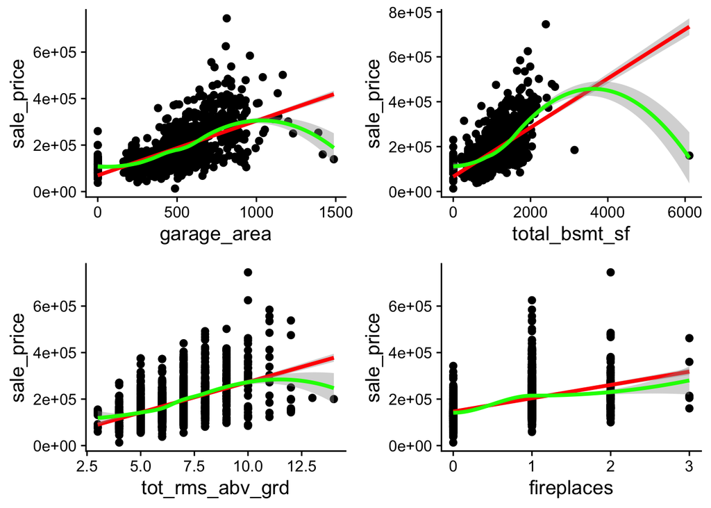

```r
data_trn |>
  select(where(is.numeric) &!sale_price) |>
  names() |>   # pass in the variable names as strings
  map(\(name) plot_scatter(df = data_trn, x = name, y = "sale_price")) |>
  plot_grid(plotlist = _, ncol = 2)
```

```r
# use warnings() to explore these warnings
# Looks like we are getting a warning because of missing observations -- no biggie!
# The lowess line is having some trouble with fit but this is really just a visual
# aid so we're not concerned.
```

**Bivariate Relationship notes**: *There is a pretty strong relationship between basement square footage and sale price which is encouraging. Total number of rooms and garage also hold interesting relationships – they appear to have a strong linear relationship with sale_price but drop off after around 10 rooms for total rooms. For garage areas above 1000 square feet, we wonder if this is potentially related to the type of property the residence is – while some houses with many rooms and large garages may be mansions, others may be multi-family homes with lower sale prices.*

*One possibly useful transformation: let’s see what it looks like if we take the log of `sale_price`:*

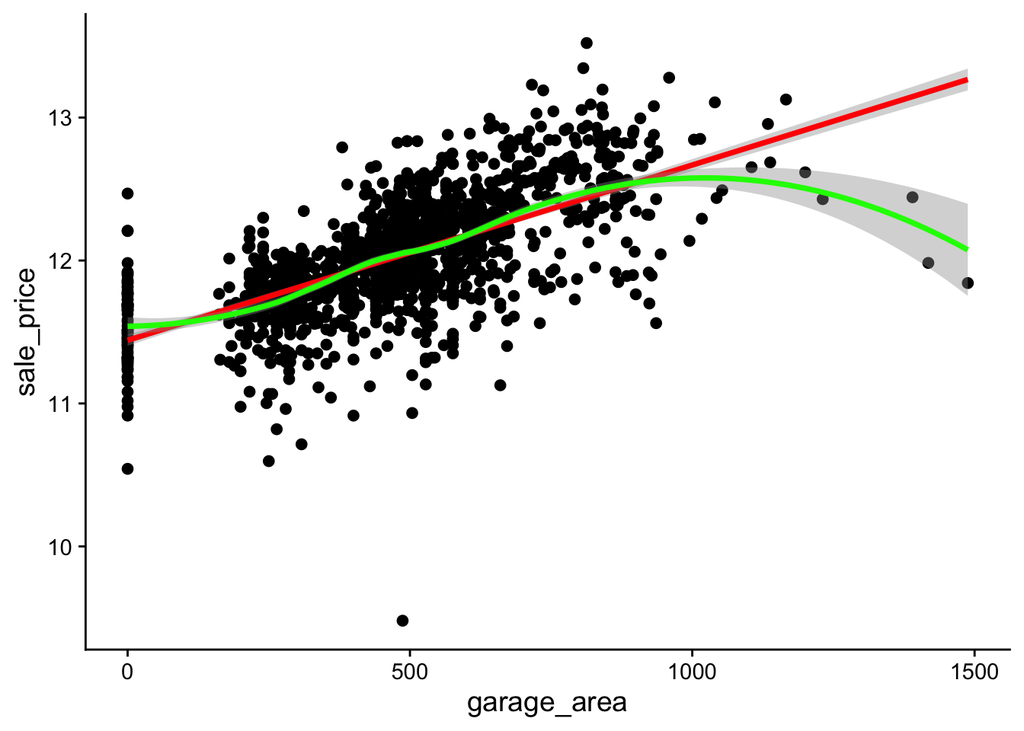

```r
data_trn |>
  filter(!is.na(garage_area)) |> # this removes the warning due to missing value
  mutate(sale_price = log(sale_price)) |>
  plot_scatter("garage_area", "sale_price")
```

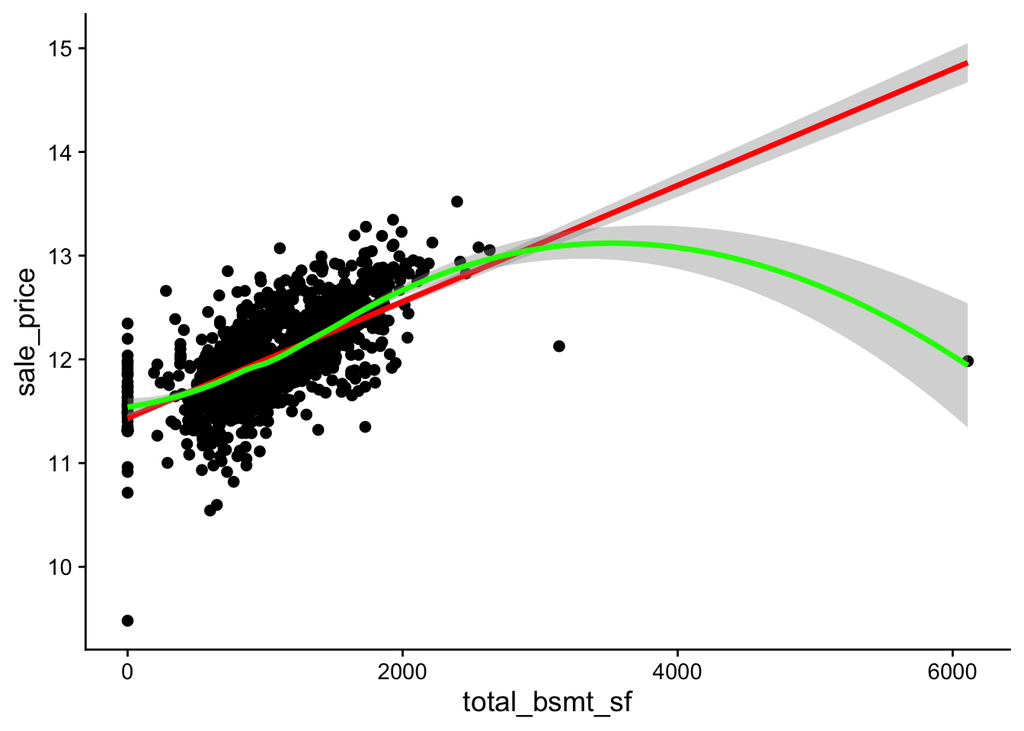

```r
data_trn |>
  mutate(sale_price = log(sale_price)) |>
  plot_scatter("total_bsmt_sf", "sale_price")
```

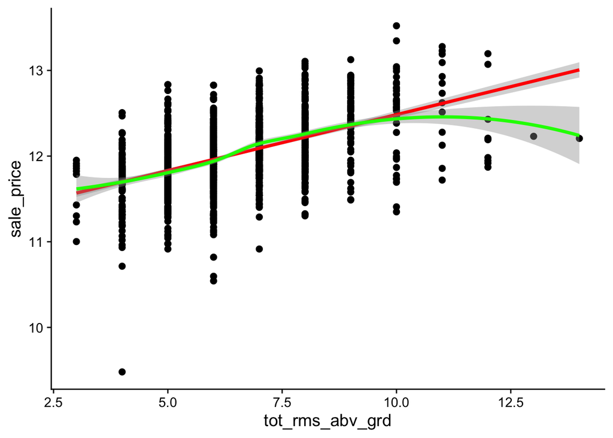

```r
data_trn |>
  mutate(sale_price = log(sale_price)) |>
  plot_scatter("tot_rms_abv_grd", "sale_price")
```

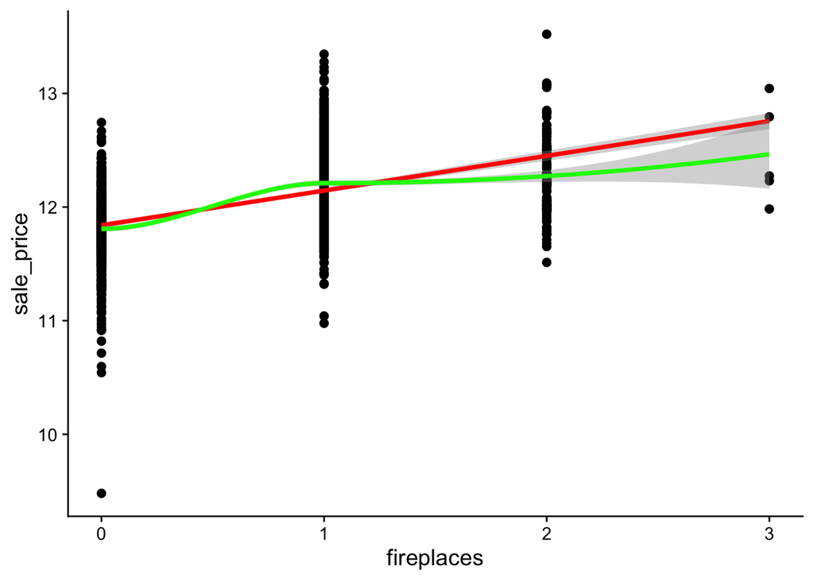

```r
data_trn |>
  mutate(sale_price = log(sale_price)) |>
  plot_scatter("fireplaces", "sale_price")
```

```r
# The warnings about lowess lines are here too
# We suppressed them for the full code chunk because we understand all of them
# Use #| warning: false at the top of the code chunk to do this
# ONLY use this once you understand what the warning is!!!
```

### Correlations

> Convert any ordinal predictors to numeric, `select()` down to numeric variables, and plot all variable correlations with `sale_price`. What correlations stand out to you?

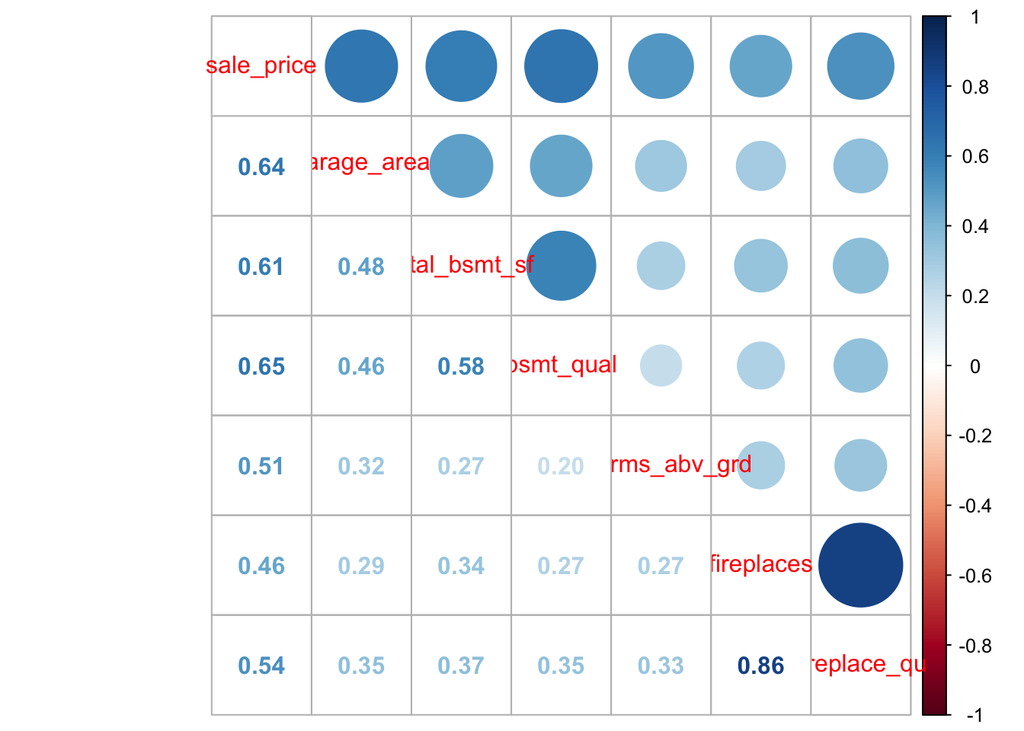

```r
data_trn |>
  mutate(bsmt_qual = as.numeric(bsmt_qual),
         fireplace_qu = as.numeric(fireplace_qu)) |>
  select(where(is.numeric)) |>
  cor(use = "pairwise.complete.obs") |> # again, to handle missing values
  corrplot::corrplot.mixed()
```

**Correlation notes:** *This looks pretty good – all of our numeric variables seem to be moderately correlated with the outcome. Maybe there was a benefit to replacing the NAs in the quality variables.*

### Categorical variables

> Now choose the best plot(s) to visualize the relationship between your categorical predictors and `sale_price()`. What relationships stand out to you?

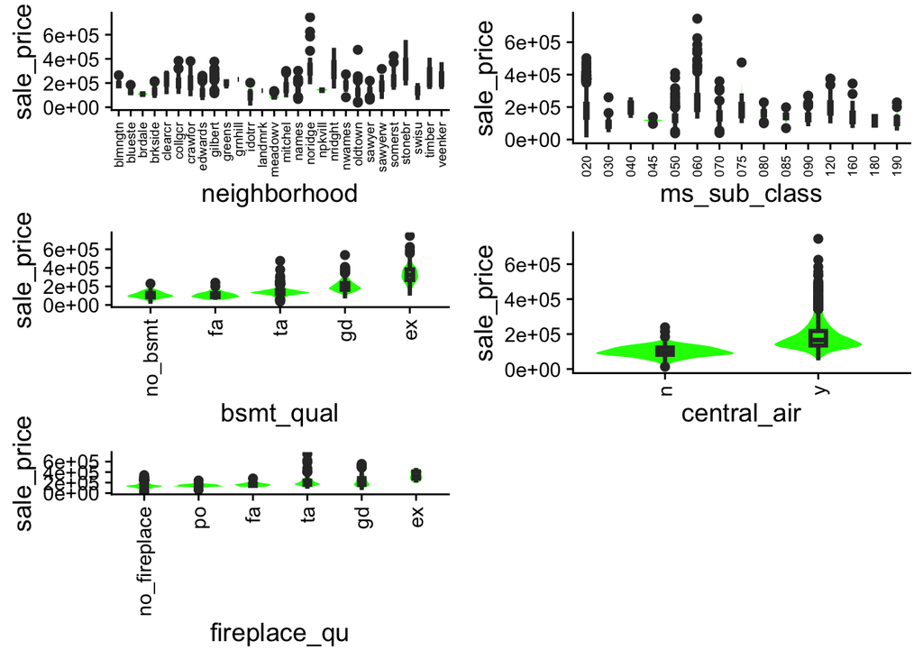

```r
# We like starting with grouped box violin plots to get oriented
data_trn |>
  select(where(is.factor)) |>
  names() |>
  map(\(name) plot_grouped_box_violin(df = data_trn, x = name, y = "sale_price")) |>
  plot_grid(plotlist = _, ncol = 2)
```

```r
# We left this warning to remind us that some of the groups will be missing from
# these plots
```

**Categorical bivariate notes:** *Linear looking relationship with `bsmt_qual`, but missing poor quality in this set. Possible that having a poor basement is worse than not having one. Similar pattern seen with fireplace quality as well as central air.*

### Guided categorical exploration

> `ms_sub_class` is a mysterious variable – take a closer look at it’s relationship with `sale_price`. Be sure that you are examining both the variable distribution as well as the relationship with `sale_price`. You may also find it helpful to consult the data dictionary to see what types of homes the numeric codes represent.

> Do some types of homes generally sell for more than others? Is there anything surprising to you? (You may find it useful to order your `ms_sub_class` factor based on the values of `sale_price`)

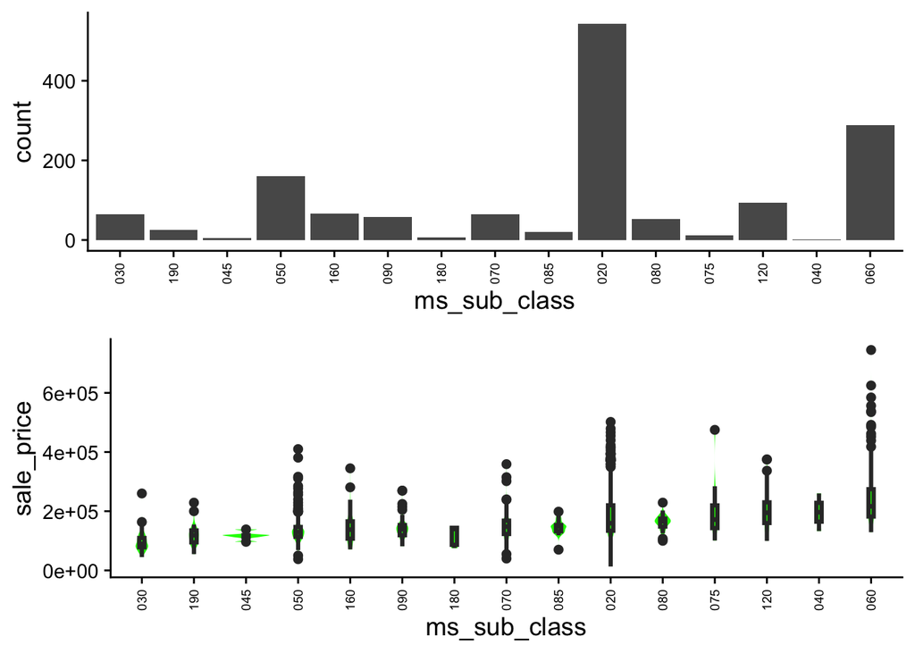

```r
# Order levels of the categorical predictor by the outcome.
data_trn |>
  plot_categorical("ms_sub_class","sale_price", ordered = TRUE)|>
   plot_grid(plotlist = _, ncol = 1)
```

**Guided categorical exploration notes:** *Write out what the codes stand to help group these together a little more:*

030: 1 story, pre 1945 045: 1.5 story unfinished 190: 2 family home 180: multilevel planned unit development (pud) 160: 2 story pud, 1946+ 050: 1.5 story finished 090: duplex 040: 1 story finished attic 150: 1-1/2 story pud - all ages 085: split foyer 070: 2 story pre 1945 020: 1 story 1946+ (most common) 080: split/multilevel 120: 1 story pud 1946+ 075: 2.5 story 060: 2 story 1946+ (second most common)

*The relationship with price is more complex than just more stories = higher price or older = lower price. In particular, we were surprised by the wide spread in `sale_price` of the three PUD (planned unit development) property types. Maybe something to do with location?*

### Categorical/categorical relationships

> Use this space to examine how the relationship between `ms_sub_class` and `sale_price` might be related to another categorical variable in our data. You may choose any categorical variable that you think might help you better understand `ms_sub_class`. Are you noticing any patterns across levels?

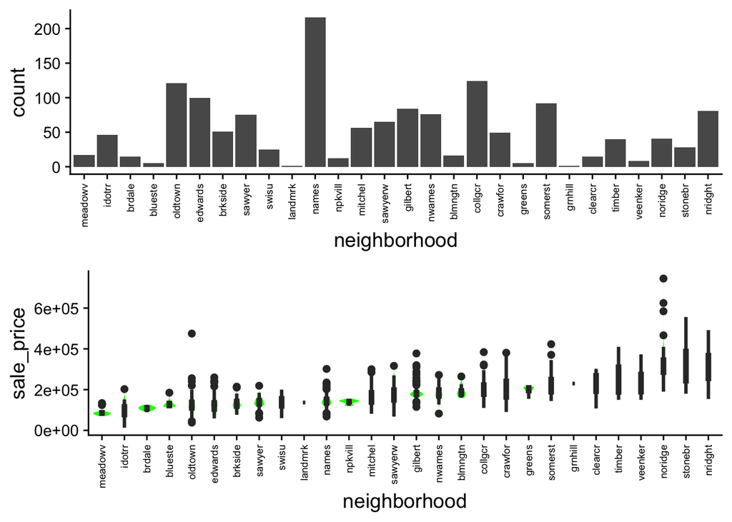

```r
# Check on how the price of a building sale may be affected by the neighborhood its in.
# First get a good look at neighborhood:

data_trn |>
  plot_categorical("neighborhood", "sale_price", ordered = TRUE) |>
   plot_grid(plotlist = _, ncol = 1)
```

```r
# left warnings again
```

**Cat/Cat Notes:** *There are some neighborhoods that seem to have higher sale_prices on average, but some barely have any observations. Adding color and ordering the factor by its relationship with sale price will help us remember groups of neighborhoods in the next step as we look at the neighborhoods of various dwelling types and sales.*

*Let’s start just by looking at the three PUD home type sales and their neighborhoods. Since color is assigned based on the relationship with y, keep the following color groups in your head when we look at the next set of graphs:* *Red/orange = low `sale_price`,* Green/Blue = moderate `sale_price`, *Pink/Purple = high `sale_price`

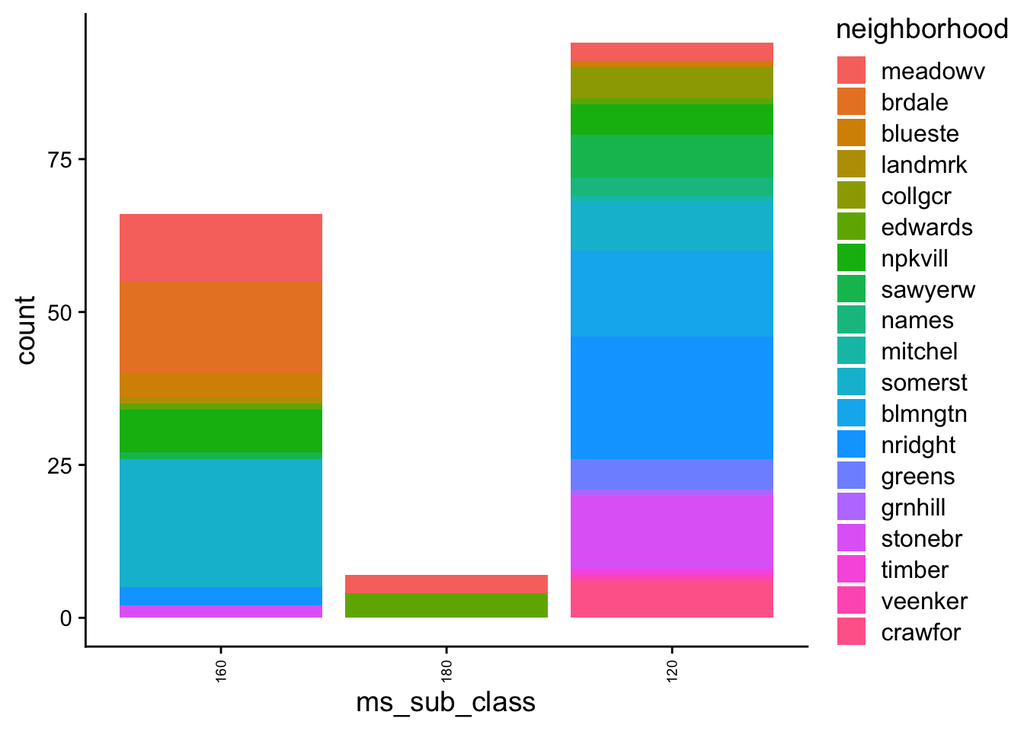

```r
data_trn |>
  filter(ms_sub_class %in% c("180","160","120")) |>
  mutate(neighborhood = fct_reorder(neighborhood, sale_price)) |>
  mutate(ms_sub_class = fct_reorder(ms_sub_class, sale_price)) |>
  plot_grouped_barplot_count("neighborhood", "ms_sub_class")
```

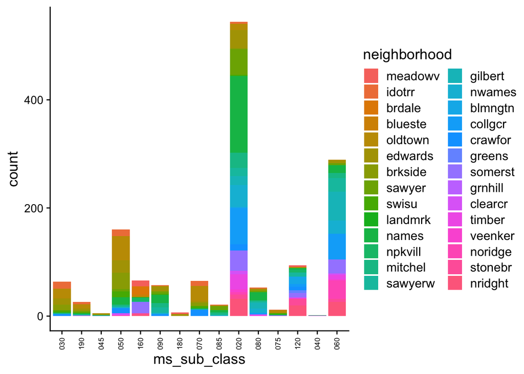

```r
data_trn |>
  mutate(neighborhood = fct_reorder(neighborhood, sale_price)) |>
  mutate(ms_sub_class = fct_reorder(ms_sub_class, sale_price)) |>
  plot_grouped_barplot_count("neighborhood", "ms_sub_class")
```

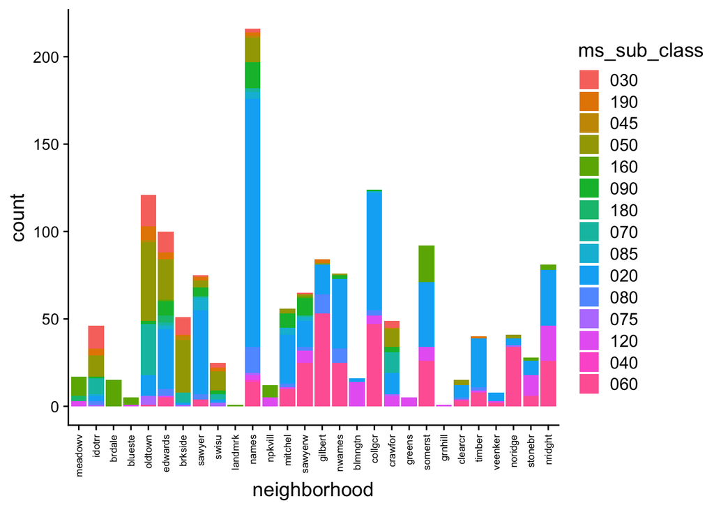

```r
# We can also look at the opposite
data_trn |>
  mutate(neighborhood = fct_reorder(neighborhood, sale_price)) |>
  mutate(ms_sub_class = fct_reorder(ms_sub_class, sale_price)) |>
  plot_grouped_barplot_count("ms_sub_class", "neighborhood")
```